# Midterm Review Problems

Felix Su

March 12, 2016

*Source file* ⇒ /Users/felixsu/ucb_classes/Sp16/STAT133/ec/mid_review_prob.Rmd

# 1.

This wrangling sequence on BabyNames will produce a short table as output. Explain what each line of the code does.

```r
BabyNames %>% #pipes the BabyNames data table into the following functions
  group_by(name) %>% #groups the cases by name to be operated on by the summarise function below
  summarise(tot = sum(count)) %>% #sums the values of the count variable fo each of the groups defined above and stored them in a new variable "tot"
  mutate(rank = rank(desc(tot))) %>% #creates a new variable "rank" that ranks the cases by their value in the "tot" column in descending order
  filter(name == "Fernando") #Selects only the cases with "Fernando" as the value for the name variable
```

# 2.

The WorkoutLog data table lists the duration and activity type of each day’s workout for the members of a rowing crew team. The variables are :

- number the team member’s jersey number
- activity giving the kind of activity, e.g. weight, sprints, etc., • date when the activity occurred
- duration of the activity in minutes

Consider the following data wrangling sequence:

```r
WorkoutLog %>%
group_by(jersey) %>%
summarise(tot = sum(duration, na.rm = TRUE)) %>% filter(activity == "sprints")
```

The sequence generates an error: Error: unknown column ‘jersey’ What went wrong? How can it be fixed? **Ans: There is no variable name ‘jersey’, so line 2 throws an error. Replace ‘jersey’ with ‘number’**

# 3.

A wrangling sequence in this form,

```r
InputData %>%
group_by(???) %>%
summarise(high = max(income), low = min(income))
```

produces an output that starts this way:

| location | sex | month | low | high |
| --- | --- | --- | --- | --- |
| DC | F | Aug | mid | poverty |
| MN | M | Nov | high | poverty |
| CA | M | Oct | high | low |

1. What variable or variables are in the place marked by `???` ? **Ans: ‘location’, ‘sex’, ’month**
2. Describe the income variable in as much detail as the information provided allows. **Ans: Income is a categorical variable that explains the wealth sector that the person/case is in. (Note: It is strange that the data table implies a categorical variable, because max() and min() result in alphabetical, not numerical ordering. ex: ‘high’ is in the low column, and ‘poverty’ is in the high column)**

# 4.

Recall the `BabyNames` data that tells how many babies of each sex were given each name, like this:

| name | sex | count | year |
| --- | --- | --- | --- |
| Francis | F | 654 | 1920 |
| Francis | M | 429 | 2012 |

In the entire data table, there are almost 2 million rows of this sort covering 134 years from 1880 onward.

For each of the following, separately, write the wrangling statements to create a new data table

1. containing only the years on or after 2000.

```r
BabyNames %>%
  filter(year >= 2000) %>%
  head(2)
```

[output not shown]

```r
BabyNames %>%
  group_by(year,name) %>%
  summarise(tot = sum(count)) %>%
  filter(tot >= 20) %>%
  head(2)
```

[output not shown]

```r
BabyNames %>%
  group_by(name) %>%
  summarise(year_count = n_distinct(year)) %>%
  filter(year_count >= 120) %>%
  head(2)
```

| name | year_count |
| --- | --- |
| Aaron | 134 |
| Abbie | 134 |

# 5

Consider this plot made with `geom_density()`

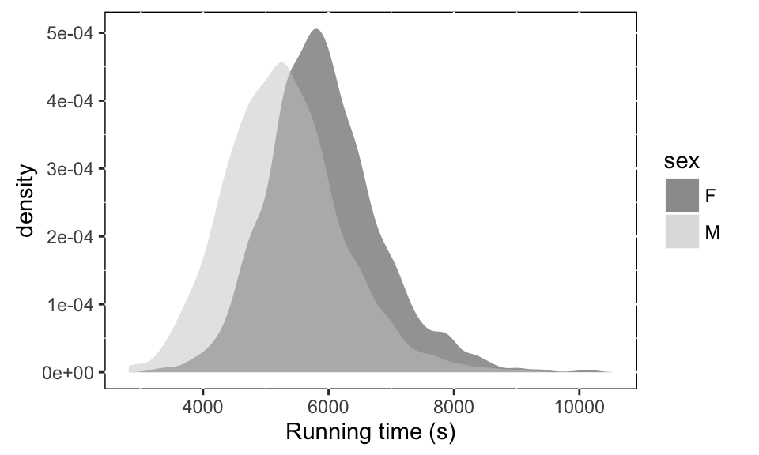

What do the glyph-ready data look like? That is,

- What are the variables? **Ans: net (running time), sex**
- Are they quantitative or categorical? **Ans: net is quantitative, sex is categorical**
- What are the levels for any categorical variable. **Ans: sex levels: M (male), F (female)**
- Is it likely that there are 10 or fewer cases? **Ans: No, it is very unlikely, because of the even normal distribution of the density, which implies a large data set**

# 6

Consider this plot made with `geom_boxplot()` …

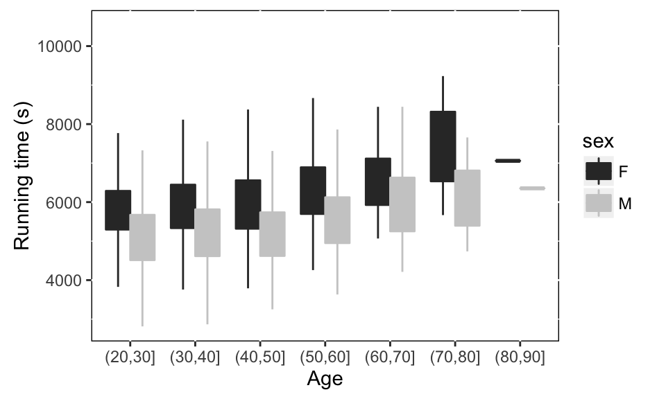

# 7

The data table gives the individual first-choice ballots for the Minneapolis 2013 mayoral election.

| Precinct | Ward | First |
| --- | --- | --- |
| P-10 | W-7 | BETSY HODGES |
| P-06 | W-10 | BOB FINE |
| P-09 | W-10 | KURTIS W. HANNA |
| P-05 | W-13 | BETSY HODGES |

The long, capitalized names for candidates are driving you crazy. You want to convert them, for all 80101 cases, to shorten them to be the first name and last initial, e.g. “Betsy H”, “Bob F”, “Kurtis H”. You can do this using the `inner_join()` verb and an auxiliary data table like this:

| variable1 | variable2 |
| --- | --- |
| BETSY HODGES | . |
| CAM WINTON | . |
| DON SAMUELS | . |
|  | . |
|  | . |

- Fill in values for `Variable2` in a way appropriate for the task.

```r
variable2 <- substr(Minneapolis2013$First, 1, regexpr(' ', Minneapolis2013$First)+1)
aux_table <- data.frame(variable1 = Minneapolis2013$First, variable2 = substr(Minneapolis2013$First, 1, regexpr(pattern = " ", Minneapolis2013$First)+1))
```

```r
Minneapolis2013 %>% inner_join(aux_table, by=c("First" = "variable"))
```

# 8

You have been given a newspaper report of the political party affiliations of each candidate, like this:

> *DFL* candidates Betsy Hodges, Mark Andrew, Bob Fine, and Don Samuels faced *Independent* Cam Winton and *Libertarian* candidates Chrisopher Zimmerman and Christopher Clark.

Given this information in this form along with data in this format:

|  | Precinct | Ward | Candidate |
| --- | --- | --- | --- |
| 7762 | P-08 | W-2 | DON SAMUELS |
| 78920 | P-08 | W-7 | JACKIE CHERRYHOMES |
| 25409 | P-03 | W-9 | BETSY HODGES |
| 31526 | P-04 | W-11 | CAM WINTON |

Describe in words how you would go about calculating the vote for each party in each precinct. **Ans: Create a auxiliary data table for the candidates’ parties and then do an innerjoin on the Minneapolis data table. Group by party and ballot, summarise by summing all ballots**

# 9

The data table `BodyTypes` gives the responses of 24,117 women and 35,829 men who are members of OkCupid to a question about their “body type”. The numbers are the counts of people giving listing that `body_type`.

Write a wrangling statement to find the proportion of women with each body type. Call this variable `fprop`. Similarly, calculate `mprop`, the proportion of men with each body type, and `ratio`, the ratio of the women’s proportion to the men’s. Finally, create a data table arranged in order from most unbalanced to most balanced. (Hint for the last step: `pmax()` will compare two variables, case by case, returning the maximum quantity of the two for each case.)

**Ans:**

```r
Types %>%
  transform(fprop = f/n(), mprop = m/n(), ratio = f/m) %>%
  arrange(desc(pmax(fprop / mprop, mprop / fprop)))
```

# 10

The following was written to find the top 3 candidates in the Minneapolis 2013 mayoral election. There are a few mistakes or omissions in the statement. Circle them and indicate how to fix them.

```r
Result <-
  Minneapolis2013 %>%
  group_by(First)
  summarise(total_votes == sum(First)) %>%
  arrange(total_votes) %>%
  head(3)
```

**Ans:** * Line 3, `group_by(First)` needs to be followed by a `%>%` * Line 4, `total_votes == sum(First)` should be total_votes = n() * Line 5, `arrange(total_votes)` should be `arrange(desc(total_votes))`

# 11

```r
tmp <- as.data.frame(cbind(1:499,testLoop(500)))
colnames(tmp) <- c("n","result")
```

Try to use ggplot to plot the result like below:

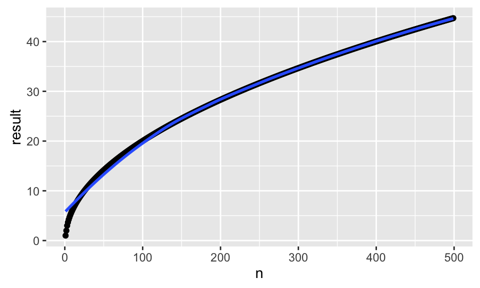

**Ans:**

```r
testLoop <- function(n)
    {
        xVec <- rep(NA, n-1)
        xVec[1] <- 1
        xVec[2] <- 2
        for( j in 3:(n-1) )
          xVec[j] <- xVec[j-1] + 2/xVec[j-1]
        return(xVec)
}
```

```r
ggplot(data = tmp,aes(x = n, y = result))+geom_point()+geom_smooth(se = FALSE)
```

# 12

Suppose we have a dataframe called `data` like below:

```r
site    transect    fish_abund  dN15_SG
B       3             19          15.22
A         1           4         10.35
A         2           12          9.06
B         1           13          14.72
A         2           5         8.99
B         1           18        14.17
B         2           25          15.66
C         1           0         11.42
A         1           5         11.35
C         3           4         10.83
C         2           4          9.97
A         3           6         8.58
C         2           8         11.74
B         3           18          16.53
```

Write the code to get the result like below:

**Ans:**

```r
data <- read.csv("/Users/felixsu/ucb_classes/Sp16/STAT133/ec/dat.csv")
data %>%
  filter(transect %in% c("1","3")) %>%
  mutate(genre = ifelse(transect == "1", "Light","Strong")) %>%
  group_by(genre) %>%
  summarise(Sum_dN15_SG = sum(fish_abund))
```

| genre | Sum_dN15_SG |
| --- | --- |
| Light | 40 |
| Strong | 47 |

# 13

Write a functon `fib` that takes a positive integer `n` and returns the nth Fibonacci number. (In R we start counting from 1 not 0.) Fibonacci numbers are as follows: 0, 1, 1, 2, 3, 5, 8. First two Fibonacci numbers are 0 and 1, respectively. Starting from the third one each Fibonacci number is equal to the sum of previous two. In other words `fib(3) = fib(2) + fib(1)` and `fib(4) = fib(3) + fib(2)` etc. **Ans:**

```r
fib <- function(n){
  if (n==1) {
    return(0)
  } else if (n==2) {
    return(1)
  } else {
    index = 3
    prev1 = 1
    prev2 = 0
    while (index<=n) {
      temp = prev2
      prev2 = prev1
      prev1 = prev1 + temp
      index = index + 1
    }
    return(prev1)
  }
}
fib(1)
```

```
## [1] 0
```

# 14

Suppose following tables are loaded to your computer. You can call them `TableA` and `TableB`, respectively.

| Year | Algeria | Brazil | Columbia |
| --- | --- | --- | --- |
| 2000 | 7 | 12 | 16 |
| 2001 | 9 | 14 | 18 |

| Country | Abbreviation |
| --- | --- |
| Algeria | DZ |
| Brazil | BR |
| Columbia | CO |

Write a code to get to the following table.

**Ans:**

```r
TableC <- TableA %>%
  gather(key = Country, value = Value, -Year) %>%
  group_by(Country) %>%
  summarize(Avg = mean(Value)) %>%
  left_join(TableB, by = c("Country"= "Country")) %>%
  select(Abbreviation, Avg)

TableC
```

| Abbreviation | Avg |
| --- | --- |
| DZ | 8 |
| BR | 13 |
| CO | 17 |

# 15

Using e while and/or a for loop and conditional expression convert `Mat`, matrix of zeros, to an identity matrix. `Mat`

| 0 | 0 | 0 | 0 | 0 |
| --- | --- | --- | --- | --- |
| 0 | 0 | 0 | 0 | 0 |
| 0 | 0 | 0 | 0 | 0 |
| 0 | 0 | 0 | 0 | 0 |
| 0 | 0 | 0 | 0 | 0 |

**Ans:**

```r
for (i in 1:5) {
  for (j in 1:5) {
    if (i==j){
      Mat[i, j] =1
    }
  }
}
Mat
```

| 1 | 0 | 0 | 0 | 0 |
| --- | --- | --- | --- | --- |
| 0 | 1 | 0 | 0 | 0 |
| 0 | 0 | 1 | 0 | 0 |
| 0 | 0 | 0 | 1 | 0 |
| 0 | 0 | 0 | 0 | 1 |

# 16

Given vector ‘asc=1:50’, answer the following questions:  
1. use ‘asc’ and for loop to generate a new vector called ‘desc’ which is the reverse of ‘asc’.  
2. use ‘asc’, for loop and while loop to update ‘asc’ so as it contains value c(1:25,25:1).  
3. use ‘asc’, for loop and if/else statement to update ‘asc’ to c(1,1,2,2,3,3……,24,24,25,25)

**Ans:**

```r
asc = 1:50

# 1)
desc=numeric(50)
for (i in 1:length(asc)){
  desc[i] = asc[51-i]
}

# 2)
for (i in 1:length(asc)){
  while (asc[i]>25){
    asc[i] = 51-asc[i]
  }
}

# 3 )
for (i in 1:length(asc)){
  if(asc[i] %% 2 == 0){
    asc[i] = asc[i]/2
  }else if(asc[i]%%2 ==1){
    asc[i] = (asc[i]+1)/2
  }
}
```

# 17

Split the a character string `University of California` into a vector of signle characters and calculate the number of `i` in it.

```r
berk <- "University of California"

count_i <- function(string) {
  str_arr <- unlist(strsplit(string, split=""))
  count <- 0
  for (i in str_arr) {
    if (i == 'i') count <- count + 1
  }
  return(count)
}
count_i(berk)
```

```
## [1] 4
```

# 18

Change data from wide to narrow format using gather function. Group Ozone, Solar.R, Wind, Temp into one variable called `type` and create another column called `value` to store their values.

```r
# built-in dataset in R
head(airquality)
```

| Ozone | Solar.R | Wind | Temp | Month | Day |
| --- | --- | --- | --- | --- | --- |
| 41 | 190 | 7.4 | 67 | 5 | 1 |
| 36 | 118 | 8.0 | 72 | 5 | 2 |
| 12 | 149 | 12.6 | 74 | 5 | 3 |
| 18 | 313 | 11.5 | 62 | 5 | 4 |
| NA | NA | 14.3 | 56 | 5 | 5 |
| 28 | NA | 14.9 | 66 | 5 | 6 |

```r
narrow <- airquality %>%
  gather(key='type', value='value', Ozone, Solar.R, Wind, Temp)

head(narrow)
```

[output not shown]

Suppose you have a data frame, `data`, as given below:

```
##   V1 V2    V3 V4
## 1  a  1 alpha 10
## 2  a  2  beta 20
## 3  b  1 gamma 30
## 4  b  2 alpha 40
## 5  c  1  beta 50
## 6  c  2 gamma 60
```

Assuming that the `tidyr` and `dplyr` libraries are already loaded, write down what the output for the following code. The final result is enough for full credit, but partial credit will be given for writing out and labelling intermediate steps.

```r
data %>%
  filter(V1 == "a") %>% # Step 1
  select(V2, V4) %>% # Step 2
  gather(key = Apple, value = Banana, V2, V4) %>% # Step 3
  mutate(Apple = Banana) # Step 4
```

| Apple | Banana |
| --- | --- |
| 1 | 1 |
| 2 | 2 |
| 10 | 10 |
| 20 | 20 |

# 20

Suppose you have a data frame, `data`, as given below.

1. Write a function called `fix_missing_99` that takes one argument: `x`, a numeric vector. The function should replace every component of `x` equal to -99 with `NA`.
2. Write a loop that replaces every -99 in `data` with `NA`. For full credit, your code must use the function in part (a) and it should continue to work without modification if additional columns are added to the data frame.
3. Write down an appropriate call from the `apply` family of functionals to perform the same task as in part (b).

| a | b | c | d | e | f |
| --- | --- | --- | --- | --- | --- |
| 1 | 6 | 1 | 5 | -99 | 1 |
| 10 | 4 | 4 | -99 | 9 | 3 |
| 7 | 9 | 5 | 4 | 1 | 4 |
| 2 | 9 | 3 | 8 | 6 | 8 |
| 1 | 10 | 5 | 9 | 8 | 6 |
| 6 | 2 | 1 | 3 | 8 | 5 |

**Ans:**

```r
# 1)
fix_missing_99 <- function(x) {
  x[x == -99] <- NA
  return(x)
}

# 2)
for(name in names(data)) {
  data[name] <- fix_missing_99(data[name])
}

# 3)
data[] <- lapply(data, fix_missing_99)
```

# 21

Given the plot below,

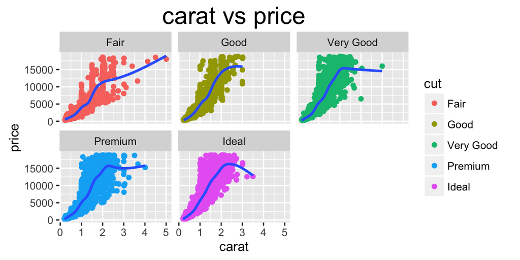

assuming the ‘ggplot2’ is already loaded and the first 6 rows of the ‘diamond’ dataset are:

[output not shown]

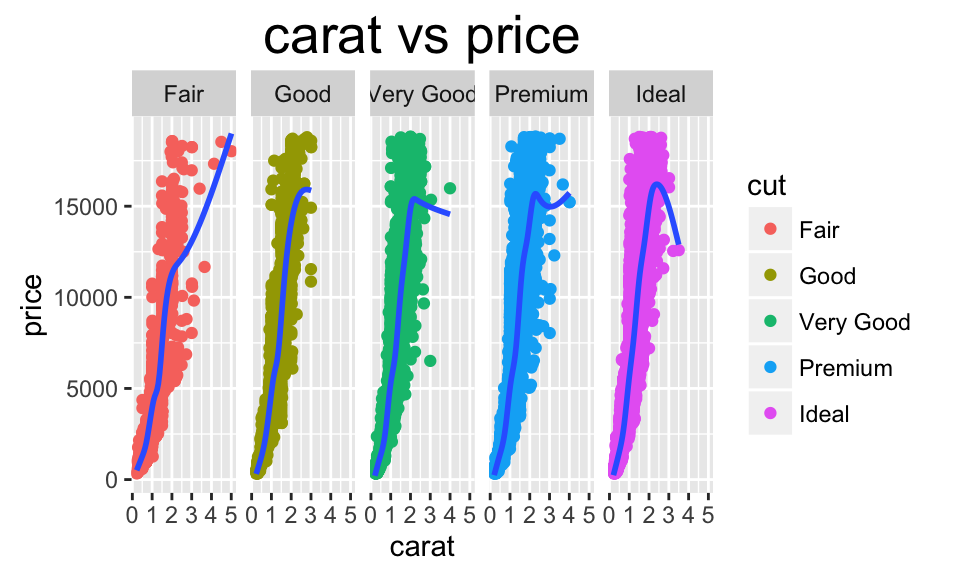

```r
diamonds %>% ggplot(aes(x=carat,y=price)) +
  geom_point(aes(col=cut)) +
  geom_smooth(se=FALSE) +
  facet_grid(.~cut) +
  labs(title = "carat vs price") +
  theme(plot.title=element_text(size=20))
```

# 22

```r
temp <-  list(c(3,7,9,6,-1),c(6,9,12,13,5), c(4,8,3,-1,-3), c(1,4,7,2,-2),c(5,7,9,4,2))
temp
```

```
## [[1]]
## [1]  3  7  9  6 -1
##
## [[2]]
## [1]  6  9 12 13  5
##
## [[3]]
## [1]  4  8  3 -1 -3
##
## [[4]]
## [1]  1  4  7  2 -2
##
## [[5]]
## [1] 5 7 9 4 2
```

1. Create a function that returns all values below zero. Call the function belowZero
2. Apply belowZero over temp using `sapply()`. Call the result freezingS

**Ans:** 1)

```r
belowZero <- function(vec){
    return(vec[vec<0])
}
```

```r
freezingS <- temp %>% sapply(belowZero)
```